# Gasoline Prices: Cleaning and Exploratory Analysis

Only the supplied local retail and FRED spot data are used. No futures. The supplied files are read directly from `data/` and are not modified. This report covers cleaning and EDA only; forecasting choices are reserved for seminar discussion. A calendar week is the unit of observation throughout.

## 1. Read data

```r
local <- read.csv("data/binghamton_weekly.csv")
wti <- read.csv("data/WCOILWTICO.csv")
brent <- read.csv("data/WCOILBRENTEU.csv")
rbob <- read.csv("data/WRGASLA.csv")

# Keep Binghamton only; the file contains other regions too.
local <- local[, c("date", "binghamton_average_gal")]
names(local) <- c("date", "local_price")
names(rbob) <- c("date", "rbob")
```

Local and RBOB prices: USD/gallon. WTI and Brent: USD/barrel. RBOB is the Los Angeles spot series WRGASLA.

The averaging conventions differ:

- **Local retail:** a regional average of posted prices observed on Mondays, rather than an average of all seven days.
- **FRED spot:** weekly averages of available daily spot closing prices, dated at the Friday week-end.

These are observation/period dates, **not confirmed publication dates**. Source definitions: [NYSERDA retail methodology](https://www.nyserda.ny.gov/Energy-Prices/Motor-Gasoline/Weekly-Average-Motor-Gasoline-Prices) and [EIA weekly spot methodology](https://www.eia.gov/dnav/pet/pet_pri_spt_s1_w.htm).

## 2. Convert dates and sort

```r
# Remove the time part from the local dates.
local$date <- as.Date(substr(local$date, 1, 10))
wti$date <- as.Date(wti$date)
brent$date <- as.Date(brent$date)
rbob$date <- as.Date(rbob$date)

local <- local[order(local$date), ]
wti <- wti[order(wti$date), ]
brent <- brent[order(brent$date), ]
rbob <- rbob[order(rbob$date), ]

str(local)
```

```
## 'data.frame':    507 obs. of  2 variables:
##  $ date       : Date, format: "2017-01-02" "2017-01-09" ...
##  $ local_price: num  2.5 2.51 2.5 2.48 2.46 2.43 2.41 2.41 2.4 2.39 ...
```

```r
str(wti)
```

```
## 'data.frame':    505 obs. of  2 variables:
##  $ date: Date, format: "2017-01-06" "2017-01-13" ...
##  $ wti : num  53.3 52.1 51.8 52.7 53.3 ...
```

```r
str(brent)
```

```
## 'data.frame':    505 obs. of  2 variables:
##  $ date : Date, format: "2017-01-06" "2017-01-13" ...
##  $ brent: num  55.1 54 54.2 54.9 55.5 ...
```

```r
str(rbob)
```

```
## 'data.frame':    505 obs. of  2 variables:
##  $ date: Date, format: "2017-01-06" "2017-01-13" ...
##  $ rbob: num  1.7 1.67 1.55 1.53 1.68 ...
```

## 3. Check missing values and duplicate dates

```r
colSums(is.na(local))
```

```
##        date local_price
##           0           0
```

```r
colSums(is.na(wti))
```

```
## date  wti
##    0    0
```

```r
colSums(is.na(brent))
```

```
##  date brent
##     0     0
```

```r
colSums(is.na(rbob))
```

```
## date rbob
##    0    0
```

```r
sum(duplicated(local$date))
```

```
## [1] 0
```

```r
sum(duplicated(wti$date))
```

```
## [1] 0
```

```r
sum(duplicated(brent$date))
```

```
## [1] 0
```

```r
sum(duplicated(rbob$date))
```

```
## [1] 0
```

```r
# Stop for review if dates repeat or existing rows contain missing values.
stopifnot(!anyNA(local), !anyNA(wti), !anyNA(brent), !anyNA(rbob))
stopifnot(!anyDuplicated(local$date), !anyDuplicated(wti$date),
          !anyDuplicated(brent$date), !anyDuplicated(rbob$date))
```

An absent week is different from an empty cell. Check both.

```r
local_weeks <- seq(min(local$date), max(local$date), by = "week")
wti_weeks <- seq(min(wti$date), max(wti$date), by = "week")
brent_weeks <- seq(min(brent$date), max(brent$date), by = "week")
rbob_weeks <- seq(min(rbob$date), max(rbob$date), by = "week")

local_weeks[!local_weeks %in% local$date]
```

```
## [1] "2024-12-30"
```

```r
wti_weeks[!wti_weeks %in% wti$date]
```

```
## Date of length 0
```

```r
brent_weeks[!brent_weeks %in% brent$date]
```

```
## Date of length 0
```

```r
rbob_weeks[!rbob_weeks %in% rbob$date]
```

```
## Date of length 0
```

Local data are missing December 30, 2024. Spot series have no missing weeks within their own ranges. Do not fill values or delete unusual prices yet.

## 4. Merge spot prices

The three spot series have Friday dates. Join on those dates. `all = TRUE` keeps all dates, even if a series has no value.

```r
spot <- merge(wti, brent, by = "date", all = TRUE)
spot <- merge(spot, rbob, by = "date", all = TRUE)
names(spot)[1] <- "spot_date"
head(spot)
```

```
##    spot_date   wti brent  rbob
## 1 2017-01-06 53.34 55.13 1.703
## 2 2017-01-13 52.07 54.02 1.671
## 3 2017-01-20 51.82 54.19 1.546
## 4 2017-01-27 52.74 54.91 1.530
## 5 2017-02-03 53.33 55.53 1.675
## 6 2017-02-10 52.88 54.48 1.725
```

```r
summary(spot)
```

```
##    spot_date               wti             brent             rbob
##  Min.   :2017-01-06   Min.   :  3.32   Min.   : 14.24   Min.   :0.369
##  1st Qu.:2019-06-07   1st Qu.: 56.12   1st Qu.: 62.29   1st Qu.:1.829
##  Median :2021-11-05   Median : 67.43   Median : 71.59   Median :2.246
##  Mean   :2021-11-05   Mean   : 67.28   Mean   : 71.98   Mean   :2.312
##  3rd Qu.:2024-04-05   3rd Qu.: 77.86   3rd Qu.: 81.93   3rd Qu.:2.608
##  Max.   :2026-09-04   Max.   :120.43   Max.   :127.40   Max.   :4.787
```

## 5. Exploratory alignment with local prices

Local dates are Mondays; spot dates mark weeks ending Fridays. We first pair each Monday with the preceding Friday for descriptive comparisons. This retains the original observation dates in separate columns; it does not change prices. This is **not yet prediction-ready** because release timing is unverified.

```r
# Keep every Monday, including the missing local week.
calendar <- data.frame(date = local_weeks)
combined <- merge(calendar, local, by = "date", all.x = TRUE)
combined$spot_date <- combined$date - 3
combined <- merge(combined, spot, by = "spot_date", all.x = TRUE)
combined <- combined[order(combined$date), ]
combined <- combined[, c("date", "spot_date", "local_price", "wti", "brent", "rbob")]

head(combined)
```

```
##         date  spot_date local_price   wti brent  rbob
## 1 2017-01-02 2016-12-30        2.50    NA    NA    NA
## 2 2017-01-09 2017-01-06        2.51 53.34 55.13 1.703
## 3 2017-01-16 2017-01-13        2.50 52.07 54.02 1.671
## 4 2017-01-23 2017-01-20        2.48 51.82 54.19 1.546
## 5 2017-01-30 2017-01-27        2.46 52.74 54.91 1.530
## 6 2017-02-06 2017-02-03        2.43 53.33 55.53 1.675
```

```r
colSums(is.na(combined))
```

```
##        date   spot_date local_price         wti       brent        rbob
##           0           0           1           3           3           3
```

```r
# Inspect incomplete rows; do not delete them.
combined[!complete.cases(combined), ]
```

```
##           date  spot_date local_price   wti brent  rbob
## 1   2017-01-02 2016-12-30        2.50    NA    NA    NA
## 418 2024-12-30 2024-12-27          NA 70.51 73.13 2.159
## 507 2026-09-14 2026-09-11        4.33    NA    NA    NA
## 508 2026-09-21 2026-09-18        4.42    NA    NA    NA
```

```r
sum(complete.cases(combined))
```

```
## [1] 504
```

## 6. Save

```r
dir.create("data/clean", recursive = TRUE, showWarnings = FALSE)
write.csv(local, "data/clean/binghamton_clean.csv", row.names = FALSE)
write.csv(wti, "data/clean/wti_clean.csv", row.names = FALSE)
write.csv(brent, "data/clean/brent_clean.csv", row.names = FALSE)
write.csv(rbob, "data/clean/rbob_la_clean.csv", row.names = FALSE)
write.csv(spot, "data/clean/spot_weekly_clean.csv", row.names = FALSE)
write.csv(combined, "data/clean/local_spot_exploratory_alignment.csv",
          row.names = FALSE, na = "")
```

No price values have been changed or filled. Keep the full history for now; choose the training period later.

## 7. Price levels over time

Separate panels keep the original units visible. Missing weeks remain gaps.

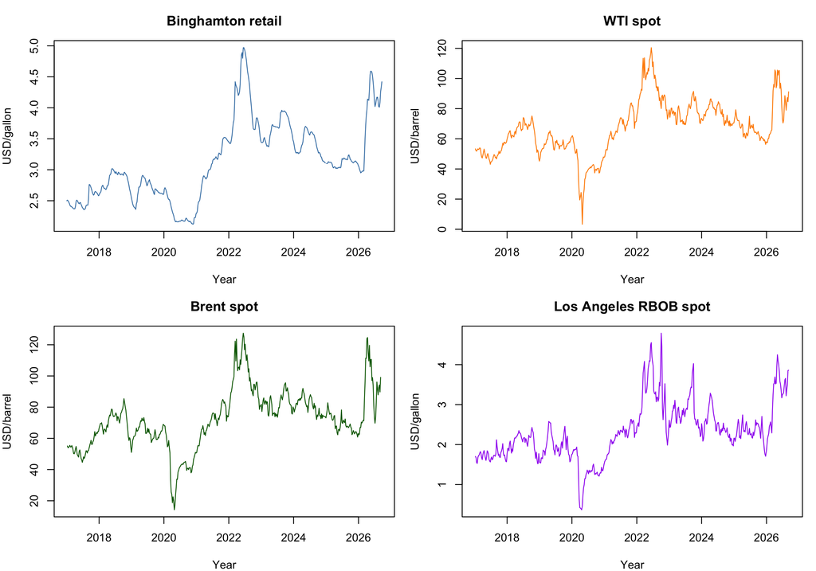

```r
knitr::opts_chunk$set(fig.path = "output/eda_", dev = "png", dpi = 120)
par(mfrow = c(2, 2), mar = c(4, 4, 3, 1))
plot(combined$date, combined$local_price, type = "l", col = "steelblue",
     main = "Binghamton retail", xlab = "Year", ylab = "USD/gallon")
plot(combined$date, combined$wti, type = "l", col = "darkorange",
     main = "WTI spot", xlab = "Year", ylab = "USD/barrel")
plot(combined$date, combined$brent, type = "l", col = "darkgreen",
     main = "Brent spot", xlab = "Year", ylab = "USD/barrel")
plot(combined$date, combined$rbob, type = "l", col = "purple",
     main = "Los Angeles RBOB spot", xlab = "Year", ylab = "USD/gallon")
```

## 8. Week-to-week price changes

Subtract the previous week’s price. If either week is missing, the change stays missing. This avoids calculating a two-week change across the missing local week.

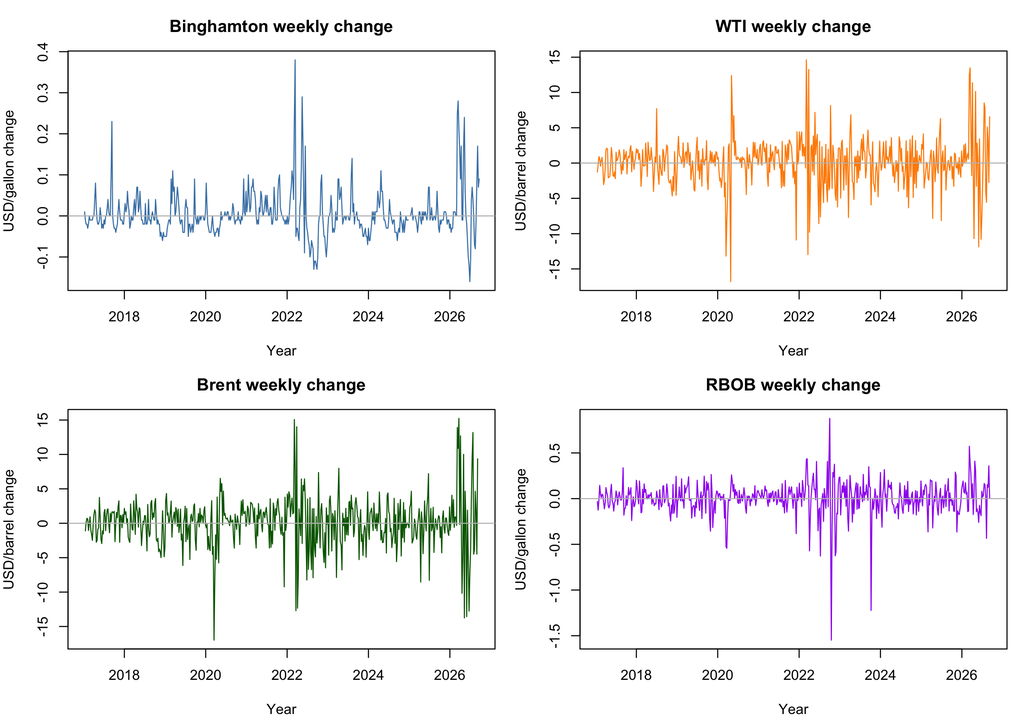

```r
changes <- data.frame(
  date = combined$date,
  local_price = c(NA, diff(combined$local_price)),
  wti = c(NA, diff(combined$wti)),
  brent = c(NA, diff(combined$brent)),
  rbob = c(NA, diff(combined$rbob))
)

par(mfrow = c(2, 2), mar = c(4, 4, 3, 1))
plot(changes$date, changes$local_price, type = "l", col = "steelblue",
     main = "Binghamton weekly change", xlab = "Year", ylab = "USD/gallon change")
abline(h = 0, col = "gray")
plot(changes$date, changes$wti, type = "l", col = "darkorange",
     main = "WTI weekly change", xlab = "Year", ylab = "USD/barrel change")
abline(h = 0, col = "gray")
plot(changes$date, changes$brent, type = "l", col = "darkgreen",
     main = "Brent weekly change", xlab = "Year", ylab = "USD/barrel change")
abline(h = 0, col = "gray")
plot(changes$date, changes$rbob, type = "l", col = "purple",
     main = "RBOB weekly change", xlab = "Year", ylab = "USD/gallon change")
abline(h = 0, col = "gray")
```

## 9. Correlation: price levels versus weekly changes

Use a common complete sample within each table. Level correlations may reflect shared trends. Change correlations describe weekly movements more directly. Neither establishes causality or guarantees forecast improvement.

```r
price_columns <- c("local_price", "wti", "brent", "rbob")
level_cor <- cor(combined[, price_columns], use = "complete.obs")
change_cor <- cor(changes[, price_columns], use = "complete.obs")

knitr::kable(round(level_cor, 3), caption = "Correlation of price levels")
```

Correlation of price levels

|  | local_price | wti | brent | rbob |
| --- | --- | --- | --- | --- |
| local_price | 1.000 | 0.926 | 0.910 | 0.904 |
| wti | 0.926 | 1.000 | 0.989 | 0.915 |
| brent | 0.910 | 0.989 | 1.000 | 0.909 |
| rbob | 0.904 | 0.915 | 0.909 | 1.000 |

```r
knitr::kable(round(change_cor, 3), caption = "Correlation of weekly changes")
```

Correlation of weekly changes

|  | local_price | wti | brent | rbob |
| --- | --- | --- | --- | --- |
| local_price | 1.000 | 0.376 | 0.373 | 0.203 |
| wti | 0.376 | 1.000 | 0.913 | 0.435 |
| brent | 0.373 | 0.913 | 1.000 | 0.438 |
| rbob | 0.203 | 0.435 | 0.438 | 1.000 |

## 10. Time lag: do spot movements lead local movements?

### Why examine time lags?

Upstream and retail prices may adjust at different times. This EDA asks whether local weekly changes are more closely associated with the nearest spot-week change or with an earlier spot-week change. It describes timing in historical observations; it does not estimate a causal transmission delay, select regression coefficients, or determine the forecast horizon.

### Exactly what do lag 0, lag 1, and lag 2 mean here?

**Lag k means k additional weekly shifts after the initial Monday/Friday pairing.** For a local observation on Monday 2024-06-17:

| Plot label | Local observation | Spot week ending | Date-label gap |
| --- | --- | --- | --- |
| Lag 0 | Mon 2024-06-17 | Fri 2024-06-14 | 3 days |
| Lag 1 | Mon 2024-06-17 | Fri 2024-06-07 | 10 days |
| Lag 2 | Mon 2024-06-17 | Fri 2024-05-31 | 17 days |

We correlate **changes**, not single prices. For example, lag 1 pairs the local change from June 10 to June 17 with the spot-week-average change from the week ending May 31 to the week ending June 7.

The general date-label gap is **3 + 7k days**. Ten days does not mean ten daily observations, a ten-day training window, or a ten-day forecast. Each lag uses hundreds of historical weekly pairs across the available years. The Friday is an entire weekly average’s end date, not an instantaneous Friday-only price or a release date. These chart definitions differ from local-price ACF lags, where lag 1 simply means seven days between two Monday observations.

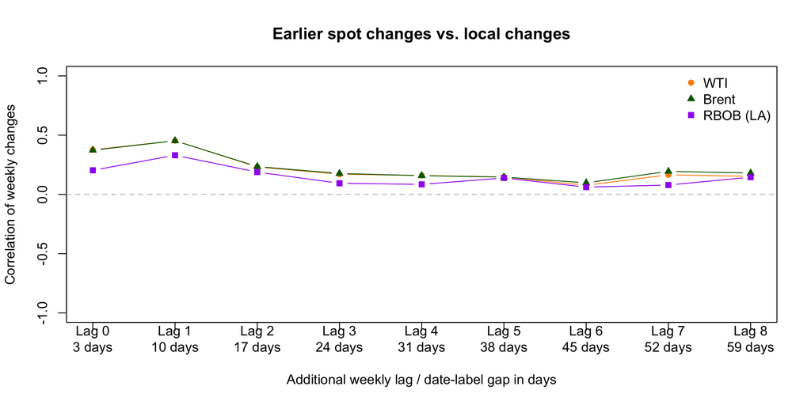

```r
lag_results <- data.frame()

for (market in c("wti", "brent", "rbob")) {
  for (k in 0:8) {
    # Shift the spot-change column down by k weeks.
    earlier_spot <- changes[[market]]
    if (k > 0) {
      earlier_spot <- c(rep(NA, k), head(earlier_spot, -k))
    }
    usable <- complete.cases(changes$local_price, earlier_spot)
    r <- cor(changes$local_price[usable], earlier_spot[usable])
    lag_results <- rbind(lag_results,
      data.frame(market = market, lag_weeks = k, date_gap_days = 3 + 7*k, correlation = r,
                 pairs = sum(usable)))
  }
}

plot(0:8, lag_results$correlation[lag_results$market == "wti"],
     type = "b", pch = 16, col = "darkorange", ylim = c(-1, 1), xaxt = "n",
     xlab = "Additional weekly lag / date-label gap in days",
     ylab = "Correlation of weekly changes", main = "Earlier spot changes vs. local changes")
axis(1, at = 0:8, labels = paste0("Lag ", 0:8, "\n", 3 + 7*(0:8), " days"))
lines(0:8, lag_results$correlation[lag_results$market == "brent"],
      type = "b", pch = 17, col = "darkgreen")
lines(0:8, lag_results$correlation[lag_results$market == "rbob"],
      type = "b", pch = 15, col = "purple")
abline(h = 0, col = "gray", lty = 2)
legend("topright", c("WTI", "Brent", "RBOB (LA)"),
       col = c("darkorange", "darkgreen", "purple"), pch = c(16, 17, 15), bty = "n")
```

```r
knitr::kable(lag_results, digits = 3)
```

| market | lag_weeks | date_gap_days | correlation | pairs |
| --- | --- | --- | --- | --- |
| wti | 0 | 3 | 0.376 | 502 |
| wti | 1 | 10 | 0.453 | 502 |
| wti | 2 | 17 | 0.232 | 502 |
| wti | 3 | 24 | 0.170 | 501 |
| wti | 4 | 31 | 0.159 | 500 |
| wti | 5 | 38 | 0.147 | 499 |
| wti | 6 | 45 | 0.077 | 498 |
| wti | 7 | 52 | 0.165 | 497 |
| wti | 8 | 59 | 0.152 | 496 |
| brent | 0 | 3 | 0.373 | 502 |
| brent | 1 | 10 | 0.453 | 502 |
| brent | 2 | 17 | 0.235 | 502 |
| brent | 3 | 24 | 0.177 | 501 |
| brent | 4 | 31 | 0.158 | 500 |
| brent | 5 | 38 | 0.146 | 499 |
| brent | 6 | 45 | 0.098 | 498 |
| brent | 7 | 52 | 0.194 | 497 |
| brent | 8 | 59 | 0.180 | 496 |
| rbob | 0 | 3 | 0.203 | 502 |
| rbob | 1 | 10 | 0.330 | 502 |
| rbob | 2 | 17 | 0.188 | 502 |
| rbob | 3 | 24 | 0.094 | 501 |
| rbob | 4 | 31 | 0.085 | 500 |
| rbob | 5 | 38 | 0.139 | 499 |
| rbob | 6 | 45 | 0.061 | 498 |
| rbob | 7 | 52 | 0.079 | 497 |
| rbob | 8 | 59 | 0.145 | 496 |

In this sample, all three markets have their largest absolute correlation among lags 0–8 at **lag 1**. The correlations are about 0.45 for WTI and Brent, and 0.33 for Los Angeles RBOB. Under our calendar pairing, lag 1 uses the spot week ending **10 days before** the Monday local observation, not simply one day or one calendar week before it. These are exploratory associations; market changes may persist across weeks and the strongest association can change by period. The graph provides candidate timing relationships for later discussion, not a chosen model. It does not show that lag 1 contributes information after controlling for local history and seasonality. Pair counts vary slightly across lags and are reported in the table; small differences in correlations should not be overread.

## 11. Local-price autocorrelation

ACF shows how the local series relates to its own past. The change-series plot helps distinguish persistence in movements from persistence in price levels. The dashed bounds are a rough white-noise reference, not a formal test of forecasting ability. Missing calendar weeks are kept in place.

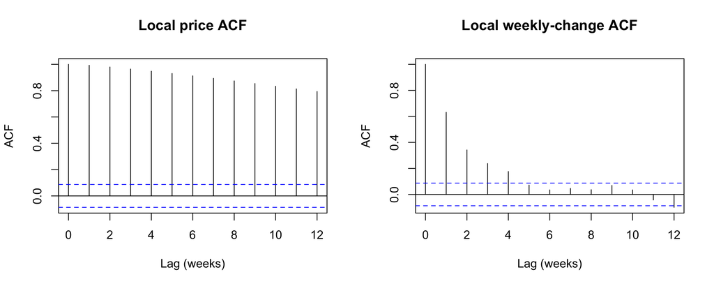

```r
par(mfrow = c(1, 2))
acf(combined$local_price, lag.max = 12, na.action = na.pass,
    main = "Local price ACF", xlab = "Lag (weeks)")
acf(changes$local_price, lag.max = 12, na.action = na.pass,
    main = "Local weekly-change ACF", xlab = "Lag (weeks)")
```

All plots are exploratory and use the full supplied history. A lag selected here must be re-evaluated using chronological validation on training data only. Publication delays still need verification before forecasting.

```r
write.csv(changes, "output/weekly_price_changes.csv", row.names = FALSE, na = "")
write.csv(level_cor, "output/level_correlations.csv")
write.csv(change_cor, "output/change_correlations.csv")
write.csv(lag_results, "output/lag_correlations.csv", row.names = FALSE)
```

## 12. Seasonal patterns

### Question and preparation

Does the same part of the year tend to have higher or lower local prices? A one-time jump in 2022 is not itself seasonality: seasonal patterns should recur across years.

Use 2017–2025, the complete **calendar-year spans** in the supplied data; the missing December 2024 week remains absent. Exclude partial-year 2026 only from this seasonal comparison, not from the earlier EDA.

Subtract each year’s observed mean to reduce differences in price levels between years. Then calculate monthly means and give each year equal weight. This is a retrospective display transformation, not a change to the saved clean prices. It does not remove within-year trends or shocks.

```r
seasonal <- local
seasonal$year <- as.integer(format(seasonal$date, "%Y"))
seasonal$month <- as.integer(format(seasonal$date, "%m"))
seasonal <- seasonal[seasonal$year <= 2025, ]
seasonal$relative_price <- seasonal$local_price -
  ave(seasonal$local_price, seasonal$year, FUN = mean)

monthly <- aggregate(relative_price ~ year + month, seasonal, mean)
monthly_average <- aggregate(relative_price ~ month, monthly, mean)
knitr::kable(monthly_average, digits = 3,
             caption = "Monthly deviation from annual mean (USD/gallon)")
```

Monthly deviation from annual mean (USD/gallon)

| month | relative_price |
| --- | --- |
| 1 | -0.183 |
| 2 | -0.160 |
| 3 | -0.072 |
| 4 | -0.017 |
| 5 | 0.094 |
| 6 | 0.122 |
| 7 | 0.120 |
| 8 | 0.101 |
| 9 | 0.063 |
| 10 | 0.009 |
| 11 | -0.002 |
| 12 | -0.074 |

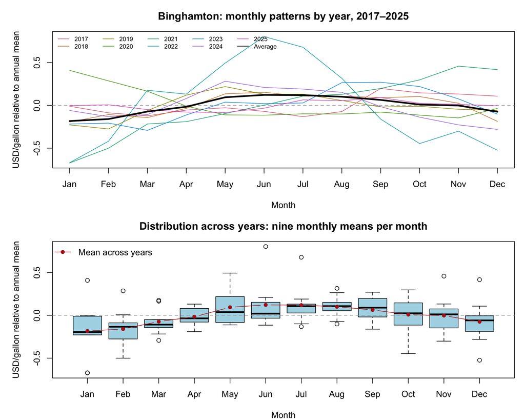

```r
par(mfrow = c(2, 1), mar = c(4, 5, 3, 1))
colors <- hcl.colors(9, "Dark 3")
plot(1:12, rep(0, 12), type = "n", ylim = range(monthly$relative_price),
     xaxt = "n", xlab = "Month", ylab = "USD/gallon relative to annual mean",
     main = "Binghamton: monthly patterns by year, 2017–2025")
axis(1, at = 1:12, labels = month.abb)
abline(h = 0, col = "gray65", lty = 2)
for (year in 2017:2025) {
  d <- monthly[monthly$year == year, ]
  lines(d$month, d$relative_price, col = colors[year - 2016])
}
lines(1:12, monthly_average$relative_price, lwd = 3, col = "black")
legend("topleft", c(as.character(2017:2025), "Average"),
       col = c(colors, "black"), lty = 1, ncol = 5, cex = 0.7, bty = "n")

boxplot(relative_price ~ month, data = monthly, names = month.abb,
        col = "lightblue", xlab = "Month",
        ylab = "USD/gallon relative to annual mean",
        main = "Distribution across years: nine monthly means per month")
abline(h = 0, col = "gray65", lty = 2)
lines(1:12, monthly_average$relative_price, type = "b", col = "firebrick", pch = 16)
legend("topleft", "Mean across years", col = "firebrick", lty = 1, pch = 16, bty = "n")
```

### Interpretation

- January–February average about $0.16–$0.18 below their annual mean, whereas May–August average about $0.09–$0.12 above it. This suggests a winter-low, summer-high pattern in price **levels**.
- The year-by-year lines and boxplots show substantial variation. In particular, 2022 has a large within-year rise and fall; the average is not a rule followed equally in every year. This is evidence of a possible pattern, not a formal estimate of a seasonal or causal effect.
- Annual seasonality is compatible with weekly observations: each weekly date occupies a position within an annual cycle of approximately 52 weeks.
- A higher summer price does not imply that prices rise every summer week. Examine weekly changes separately before interpreting seasonality in changes.

### Are weekly increases also seasonal?

Group the local weekly changes by the **later week’s month**, using 2017–2025. Changes adjacent to the missing week remain missing; no values are filled. Year-specific monthly averages give each year equal weight and show variation rather than treating all weeks as independent evidence.

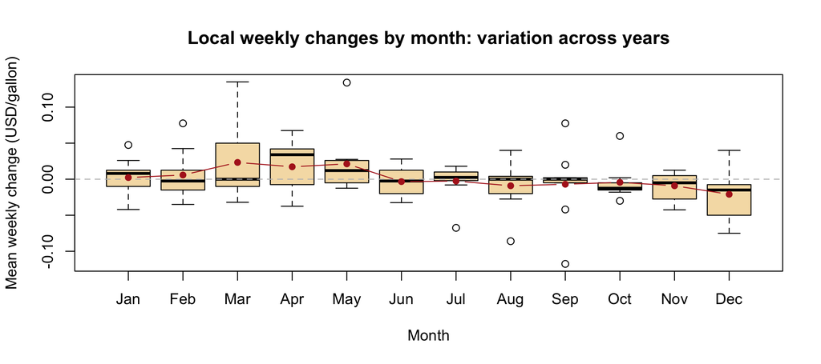

```r
seasonal_changes <- changes[, c("date", "local_price")]
seasonal_changes$year <- as.integer(format(seasonal_changes$date, "%Y"))
seasonal_changes$month <- as.integer(format(seasonal_changes$date, "%m"))
seasonal_changes <- seasonal_changes[seasonal_changes$year <= 2025, ]
monthly_changes <- aggregate(local_price ~ year + month, seasonal_changes, mean)
mean_changes <- aggregate(local_price ~ month, monthly_changes, mean)

boxplot(local_price ~ month, data = monthly_changes, names = month.abb,
        col = "wheat", xlab = "Month", ylab = "Mean weekly change (USD/gallon)",
        main = "Local weekly changes by month: variation across years")
abline(h = 0, lty = 2, col = "gray")
lines(1:12, mean_changes$local_price, type = "b", pch = 16, col = "firebrick")
```

```r
knitr::kable(mean_changes, digits = 3, caption = "Average weekly change by month")
```

Average weekly change by month

| month | local_price |
| --- | --- |
| 1 | 0.002 |
| 2 | 0.006 |
| 3 | 0.023 |
| 4 | 0.017 |
| 5 | 0.021 |
| 6 | -0.003 |
| 7 | -0.003 |
| 8 | -0.009 |
| 9 | -0.007 |
| 10 | -0.004 |
| 11 | -0.009 |
| 12 | -0.021 |

```r
write.csv(monthly, "output/seasonality_monthly_by_year.csv", row.names = FALSE)
write.csv(monthly_average, "output/seasonality_monthly_average.csv", row.names = FALSE)
write.csv(monthly_changes, "output/seasonality_changes_by_year.csv", row.names = FALSE)
```

Positive and negative year-specific monthly changes overlap in many months. The pattern in price levels is therefore easier to see than a stable month-by-month rule for price changes. Market shocks can dominate seasonal averages. These plots motivate further investigation; they do not establish forecast improvement. Annual means calculated using a full year are only for retrospective EDA and must not be used as if known during that year.

## 13. EDA takeaways

- Prices share broad movements, but level correlations can reflect common trends.
- Weekly-change correlations and calendar-preserving lags describe historical timing more directly. Lag labels do not specify a training window or horizon.
- WTI and Brent are strongly correlated with each other, so they may contain overlapping information.
- Seasonal displays suggest winter-low/summer-high local prices on average, with substantial year-to-year differences. This is exploratory evidence only.
- Missing values, source-date differences, and publication timing must remain visible. Forecast horizons and model choices are outside this report’s scope.